# Nonparametric kernel estimation

Mengyao Chen

## Overview

The source R code for *GMSMOOTH* is as follows:

```r
GMSMOOTH <- function(y, x, h) {
  n <- length(y)
  s <- c(-Inf, 0.5 * (x[-n] + x[-1]), Inf)
  s.hat <- rep(0, n)
  for (i in 1:n) {
    fx.hat <- function(z, h, x) {
      dnorm((x - z)/h)/h
    }
    a <- y[i] * integrate(fx.hat, s[i], s[i + 1], h =
                            h, x = x[i])$value
    s.hat[i] <- sum(a)
  }
  return(s.hat)
}
```

The exception to the kernel estimate is the NW estimate, where we can define the NW function is follows:

```r
NWSMOOTH <- function(h,y,x) {
  n <- length(y)
  s.hat <- rep(0, n)
  for (i in 1:n) {
    a <- fx.hat(x[i], h)
    s.hat[i] <- sum(y * a/sum(a))
  }
  return(s.hat)
}
```

In order to compare the effect of GM kernel NW method on kernel estimation in non-parametric kernel estimation, set the bandwidth and draw the kernel estimation under GM kernel NW algorithm, and compare the kernel true distribution.

```r
library(SC19076)
```

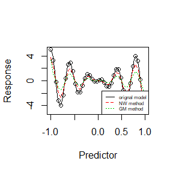

```r
x <- seq(-1, 1, length = 40)
y <- 5 * x * cos(5 * pi * x)
h <- 0.055
fx.hat <- function(z, h) {
  dnorm((z - x)/h)/h
}
NWsmooth.val <- NWSMOOTH(h, y, x)
GMsmooth.val <- GMSMOOTH(y, x, h)
plot(x, y, xlab = "Predictor", ylab = "Response", col = 1)
f <- function(x) 5 * x * cos(5 * pi * x)
curve(f, -1, 1, ylim = c(-15.5, 15.5), lty = 1, add = T, col = 1)
lines(x, NWsmooth.val, lty = 2, col = 2)
lines(x, GMsmooth.val, lty = 3, col = 3)
letters <- c("orignal model", "NW method", "GM method")
legend("bottomright", legend = letters, lty = 1:3, col = 1:3, cex = 0.5)
```

Then, we will show the influence of the choice of different window widths on the estimation

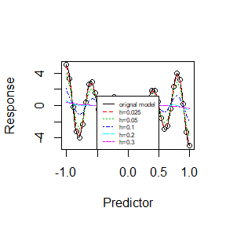

```r
x <- seq(-1, 1, length = 40)
y <- 5 * x * cos(5 * pi * x)
fx.hat <- function(z, h) {
  dnorm((z - x)/h)/h
}
NWSMOOTH <- function(h, y, x) {
  n <- length(y)
  s.hat <- rep(0, n)
  for (i in 1:n) {
    a <- fx.hat(x[i], h)
    s.hat[i] <- sum(y * a/sum(a))
  }
  return(s.hat)
}
h <- 0.025
NWsmooth.val0 <- NWSMOOTH(h, y, x)
h <- 0.05
NWsmooth.val1 <- NWSMOOTH(h, y, x)
h <- 0.1
NWsmooth.val2 <- NWSMOOTH(h, y, x)
h <- 0.2
NWsmooth.val3 <- NWSMOOTH(h, y, x)
h <- 0.3
NWsmooth.val4 <- NWSMOOTH(h, y, x)
plot(x, y, xlab = "Predictor", ylab = "Response", col = 1)
f <- function(x) 5 * x * cos(5 * pi * x)
curve(f, -1, 1, ylim = c(-15.5, 15.5), lty = 1, add = T, col = 1)
lines(x, NWsmooth.val0, lty = 2, col = 2)
lines(x, NWsmooth.val1, lty = 3, col = 3)
lines(x, NWsmooth.val2, lty = 4, col = 4)
lines(x, NWsmooth.val3, lty = 5, col = 5)
lines(x, NWsmooth.val4, lty = 6, col = 6)
letters <- c("orignal model", "h=0.025", "h=0.05",
"h=0.1", "h=0.2", "h=0.3")
legend("bottom", legend = letters, lty = 1:6, col = 1:6, cex = 0.5)
```

It can be seen that the larger the window width, the smoother the estimation, the larger the error, the smaller the window width, the less smooth the estimation, but the goodness of fit has been improved, but it is also easy to overfit.

## HomeWork 1

## Text

I am very happy to learn the course of statistical calculation, which in my opinion is a very practical course.It mainly use R in class. Learning R is very interesting. I hope I can not only learn the course but also have fun in the future study.

The homework for the first class is to use Markdown to write texts,figures and tables. This is the demonstration result of my homework.

## Tables

Here is a table:

```r
data(occupationalStatus)
head(occupationalStatus)
```

```
##       destination
## origin   1   2   3   4   5   6   7   8
##      1  50  19  26   8   7  11   6   2
##      2  16  40  34  18  11  20   8   3
##      3  12  35  65  66  35  88  23  21
##      4  11  20  58 110  40 183  64  32
##      5   2   8  12  23  25  46  28  12
##      6  12  28 102 162  90 554 230 177
```

```r
summary(occupationalStatus)
```

```
## Number of cases in table: 3498
## Number of factors: 2
## Test for independence of all factors:
##  Chisq = 1416, df = 49, p-value = 2.519e-264
##  Chi-squared approximation may be incorrect
```

## Including Plots

Here is a figure:

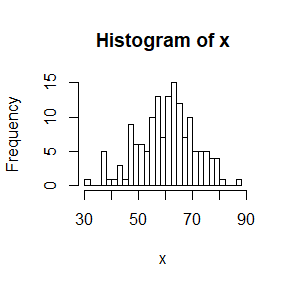

## Homework 2

## Question 1

The Rayleigh density is $f(x)=\frac{x}{\sigma^{2}} e^{-x^{2} /\left(2 \sigma^{2}\right)}, \quad x \geq 0, \sigma>0$ Develop an algorithm to generate random samples from a Rayleigh($\sigma$) distribution. Generate Rayleigh($\sigma$) samples for several choices of $\sigma>0$and check that the mode of the generated samples is close to the theoretical mode $\sigma>0$ (check the histogram).

## Answer 1

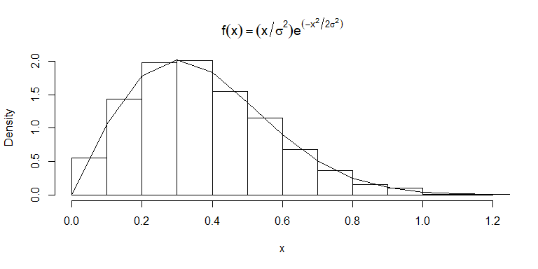

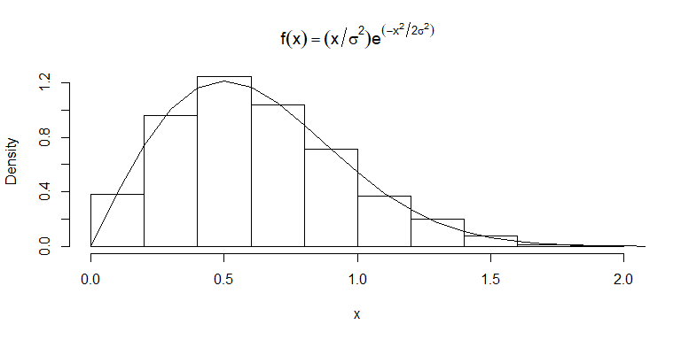

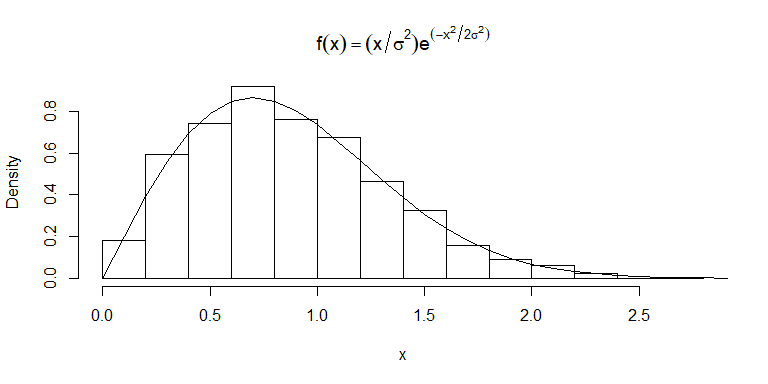

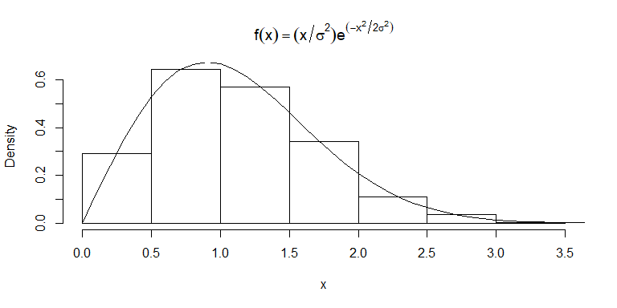

```r
set.seed(123)
n<-1000
u<-runif(n)

### several choices of σ
sigma=c(0.3,0.5,0.7,0.9)
for (i in sigma){
x=sqrt(-2*(i)^2*logb(1-u))

### Generate Rayleigh samples
hist(x,prob=TRUE,
     main=expression(f(x)==(x/sigma^2)*e^(-x^2/2*sigma^2)))
y <- seq(0, 10, .1)

### check that the mode of the generated samples is close to the theoretical mode
lines(y, (y/i^2)*exp((-y^2)/(2*(i)^2)))
}
```

The above images are obtained successively with different sigma values σ=0.3,0.5,0.7,0.9. And the comparison between the histogram and the density function graph shows that the sample is relatively close to the theoretical value.

## Question2

Generate a random sample of size 1000 from a normal location mixture. The components of the mixture have$\mathrm{N}(0,1)$ and $\mathrm{N}(3,1)$ distributions with mixing probabilities $p1$ and $p2 =1 − p1$. Graph the histogram of the sample with density superimposed, for $p1 =0.75$. Repeat with different values for $p1$ and observe whether the empirical distribution of the mixture appears to be bimodal. Make a conjecture about the values of $p1$ that produce bimodal mixtures.

## Answer2

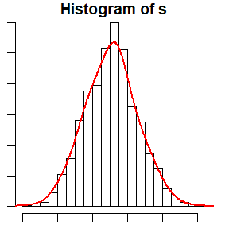

```r
set.seed(123)
n <- 1000
x1 <- rnorm(n, 0, 1)
x2 <- rnorm(n, 3, 1)

###Generate a random sample of size 1000
s <- x1 + x2
u <- runif(n)

### Graph the histogram when p1 =0.75
k <- as.integer(u > 0.75) #vector of 0’s and 1’s
x<-k*x1+ (1-k) * x2  #the mixture
par(mar=c(1,1,1,1))#two graphs per page
hist(s, freq = F, breaks = 30)
lines(density(s, bw=.5), col="red", lwd=2)
```

```r
n <- 1000
mean_s <- c(0, 3)

### Repeat with different values for p1
y<- sample(c("head", "tail"), size = n, replace = TRUE, prob = c(0.6, 0.4))
x <- rnorm(n = 1000, mean = mean_s[1])
tails <- y %in% c("tail")
x[tails] <- rnorm(sum(tails), mean = mean_s[2])
require(lattice)
```

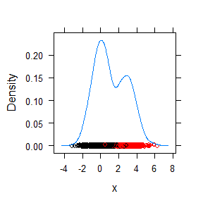

```r
densityplot(~x, par.settings = list(plot.symbol = list(col = factor(y))))
```

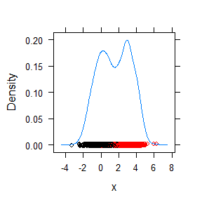

```r
y<- sample(c("head", "tail"), size = n, replace = TRUE, prob = c(0.5, 0.5))
x <- rnorm(n = 1000, mean = mean_s[1])
tails <- y %in% c("tail")
x[tails] <- rnorm(sum(tails), mean = mean_s[2])
require(lattice)
densityplot(~x, par.settings = list(plot.symbol = list(col = factor(y))))
```

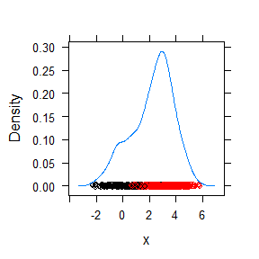

```r
y<- sample(c("head", "tail"), size = n, replace = TRUE, prob = c(0.25, 0.75))
x <- rnorm(n = 1000, mean = mean_s[1])
tails <- y %in% c("tail")
x[tails] <- rnorm(sum(tails), mean = mean_s[2])
require(lattice)
densityplot(~x, par.settings = list(plot.symbol = list(col = factor(y))))
```

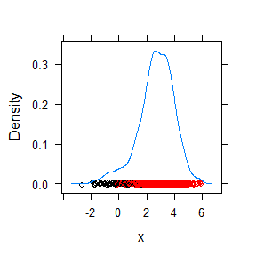

```r
y<- sample(c("head", "tail"), size = n, replace = TRUE, prob = c(0.1, 0.9))
x <- rnorm(n = 1000, mean = mean_s[1])
tails <- y %in% c("tail")
x[tails] <- rnorm(sum(tails), mean = mean_s[2])
require(lattice)
densityplot(~x, par.settings = list(plot.symbol = list(col = factor(y))))
```

Make a conjecture

Combined with the figures, we can see that when p is closer to 0.5, the bimodal performance is more obvious, and when p1 is gradually away from 0.5, It’s not obvious.

## Question3

Write a function to generate a random sample from a Wd(Σ,n)(Wishart) distribution for $n>d+1 ≥ 1$, based on Bartlett’s decomposition.

## Answer3

```r
require(graphics)
### generate a funtion
runif.wis<-function(sigma,n){
  p<-ncol(sigma)
  l<-chol(sigma)
  A<-matrix(ncol=p,nrow=p)
  for(i in 1:p){
  for(j in 1:p){
    A[i,j]=rnorm(1,0.1)
  }
  }
  A[lower.tri(A)]=0
  c<-numeric(p)
  for (i in 1:p){
    c[i]=rchisq(1,n-i+1)
    A[i,i]=c[i]
  }
  s<-l%*%A%*%t(A)%*%t(l)
  return(s)
}
```

```r
### generate  random sample from Wishart
m<-matrix(c(5,1,1,2),2,2)
k<-2*diag(8)
sigma1<-m
sigma2<-k
n<-18
runif.wis(sigma1,n)
```

```
##           [,1]     [,2]
## [1,] 3645.8306 385.0252
## [2,]  385.0252 893.9999
```

```r
runif.wis(sigma2,n)
```

```
##             [,1]        [,2]       [,3]       [,4]       [,5]       [,6]
## [1,] 405.4084245   20.743233 -15.879325  47.528103 -25.486407  28.022574
## [2,]  20.7432333 1359.931132  15.083975  35.769957  18.696972  13.481465
## [3,] -15.8793253   15.083975 322.696560  33.978733 -55.078204   1.329807
## [4,]  47.5281025   35.769957  33.978733 551.107089  13.277672   4.138431
## [5,] -25.4864072   18.696972 -55.078204  13.277672 685.408182   2.504223
## [6,]  28.0225741   13.481465   1.329807   4.138431   2.504223 381.009206
## [7,]  -6.0215793   -4.681332   1.215766   8.674012   5.591011  -9.959489
## [8,]  -0.8125895   76.785227  61.106663 -17.690942   1.794394  -1.597250
##           [,7]        [,8]
## [1,] -6.021579  -0.8125895
## [2,] -4.681332  76.7852269
## [3,]  1.215766  61.1066634
## [4,]  8.674012 -17.6909416
## [5,]  5.591011   1.7943942
## [6,] -9.959489  -1.5972496
## [7,] 44.211067  10.4549480
## [8,] 10.454948 925.7437736
```

## HomeWork 3

## Questuon1

Compute a Monte Carlo estimate of
$$\int_{0}^{\pi / 3} \sin t d t$$
and compare your estimate with the exact value of the integral.

##Answer1

```r
set.seed(0)
m<-10000
t<-runif(m,min=0,max=pi/3)

### Compute a Monte Carlo estimate
theta.hat<-mean(sin(t))*(pi/3)
print(theta.hat)
```

```
## [1] 0.4998228
```

```r
### compare your estimate with the exact value of the integral
print((cos(0)-cos(pi/3))-theta.hat)
```

```
## [1] 0.0001771703
```

##Question2

Use Monte Carlo integration with antithetic variables to estimate
$$\int_{0}^{1} \frac{e^{-x}}{1+x^{2}} d x$$
and find the approximate reduction in variance as a percentage of the variance without variance reduction.

##Answer2

```r
set.seed(123)

## antithetic variables to estimate
MC.Phi <- function(x, R = 10000, antithetic = TRUE) {
u <- runif(R/2)
if (!antithetic)
v <- runif(R/2) else
v<-1- u
u <- c(u, v)
theta.hat <- numeric(length(x))
for (i in 0:length(x)) {
g <- mean(exp(-u*x)/(1+(u*x)^2))
}
g
}
```

```r
set.seed(123)
MC1 <- MC.Phi(1, anti = FALSE)
print(MC1)
```

```
## [1] 0.5263106
```

```r
set.seed(123)
MC2 <- MC.Phi(1)
print(MC2)
```

```
## [1] 0.5246837
```

```r
set.seed(123)
m <- 10000
MC1 <- MC2 <- numeric(m)
x <- 1
for (i in 1:m){
   MC1[i] <- MC.Phi(x, R = 1000, anti = FALSE)
   MC2[i] <- MC.Phi(x, R = 1000)
}
 print(sd(MC1))
```

```
## [1] 0.007756972
```

```r
 print(sd(MC2))
```

```
## [1] 0.001475217
```

```r
 ## approximate reduction in variance
 print((var(MC1) - var(MC2))/var(MC1))
```

```
## [1] 0.9638317
```

## Question3

Obtain the stratified importance sampling estimate in Example 5.13 and compare it with the result of Example 5.10.

##Answer3

```r
m<-10000   # number of replicates
set.seed(0)
k<-5      # number of strata
r<-m/k
N<-50     # number of times to repeat the estimation
T2<-numeric(k)
estimates<-matrix(0,N,2)
g<-function(x) {
  exp(-x)/(1+x^2)*(x>0)*(x<1)
}
## stratified importance sampling
for (j in 1:N) {
for (i in 1:k) {

    u<-c(0,0.2,0.4,0.6,0.8,1)
    q<--log(1-u*(1-exp(-1)))
    u1<-runif(m/5)
    y<--log(exp(-q[i])-u1/5*(1-exp(-1)))
    f1<-g(y)/(5*exp(-y)/(1-exp(-1)))
    T2[i]<-mean(f1)
}
 estimates[j,2]<-sum(T2)

##inverse transformated method

  u2<-runif(m)
  x<--log(1-u2*(1-exp(-1)))
  f2<-g(x)/(exp(-x)/(1-exp(-1)))
  estimates[j,1]<-mean(f2)
}



print(estimates)
```

```
##            [,1]      [,2]
##  [1,] 0.5245498 0.5246857
##  [2,] 0.5249511 0.5250183
##  [3,] 0.5239855 0.5245600
##  [4,] 0.5251879 0.5248100
##  [5,] 0.5256952 0.5248839
##  [6,] 0.5251446 0.5249146
##  [7,] 0.5242177 0.5249454
##  [8,] 0.5248377 0.5245311
##  [9,] 0.5241379 0.5251162
## [10,] 0.5240995 0.5246340
## [11,] 0.5248375 0.5249225
## [12,] 0.5251257 0.5245562
## [13,] 0.5249633 0.5251531
## [14,] 0.5251238 0.5249914
```

[output cut: 36 more lines]

```r
apply(estimates,2,mean)
```

```
## [1] 0.5247310 0.5248062
```

```r
apply(estimates,2,var)
```

```
## [1] 1.149196e-06 4.634811e-08
```

```r
print((var(estimates[,1])-var(estimates[,2]))/var(estimates[,1]))
```

```
## [1] 0.9596691
```

## Homework 4

## Question1

Suppose a 95% symmetric t-interval is applied to estimate a mean, but the sample data are non-normal. Then the probability that the confidence interval covers the mean is not necessarily equal to 0.95. Use a Monte Carlo experiment to estimate the coverage probability of the t-interval for random samples of χ2(2) data with sample size n = 20. Compare your t-interval results with the simulation results in Example 6.4. (The t-interval should be more robust to departures from normality than the interval for variance.)

## Answer1

### estimate the coverage probability

```r
set.seed(0)
n<-20
alpha <- .05
# sample mean of x : mean(x)
# standard deviation of x : sd(x)
# the 97.5th percentile of the t-distribution with n degrees of freedom : qt(0.975, n)

inORnot <- function(alpha, n, mu) {

   x <- rchisq(n, df = 2)

  L = mean(x) - qt(1 - alpha / 2, n - 1)*sd(x)/sqrt(n)
  U = mean(x) + qt(1 - alpha / 2, n - 1)*sd(x)/sqrt(n)

  return(L <= mu & U >= mu)

}

covPro <- function(alpha, S, n) {

  cum = 0
  for (i in 1:S) cum = cum + inORnot(alpha, n, mu = 2)
  return(cum / S)

}

 covPro(alpha = 0.05, S = 1000, n = 20)
```

```
## [1] 0.929
```

### Compare the t-interval results with the simulation results in Example 6.4

```r
set.seed(0)
n<-20
alpha <- .05
UCL <- replicate(1000, expr = {
  x <- rchisq(n, df=2)
  (n-1) * var(x) / qchisq(alpha, df = n-1)
  })
#count the number of intervals that contain sigma^2=4
sum(UCL > 4)
```

```
## [1] 806
```

```r
#or compute the mean to get the confidence level
mean(UCL > 4)
```

```
## [1] 0.806
```

```r
# from the answer we can know that The t-interval(92.9%) is more robust to departures from normality than the interval for variance which is 80.6%.
```

## Question2

Estimate the 0.025, 0.05, 0.95, and 0.975 quantiles of the skewness $\sqrt{b_{1}}$ under normality by a Monte Carlo experiment. Compute the standard error of the estimates from (2.14) using the normal approximation for the density (with exact variance formula). Compare the estimated quantiles with the quantiles of the large sample approximation $\sqrt{b_{1}} \approx N(0,6 / n)$.

## Answer2

### Estimate quantiles

```r
n=1000
set.seed(0)
sk<- function(x) {
  #computes the sample skewness coeff
  xbar <- mean(x)
  m3 <- mean((x - xbar)^3)
  m2 <- mean((x - xbar)^2)
  return( m3 / m2^1.5 )
}
skew<-numeric(50)
for (i in 1:50){
  x<-rnorm(1000)
  skew[i]<-sk(x)
}
quantile(skew,c(0.025,0.05,0.95,0.975))
```

```
##       2.5%         5%        95%      97.5%
## -0.1556104 -0.1303459  0.1214173  0.1300384
```

### compute the standard error

```r
varq<-function(n,q,xq){
    return (q*(1-q)/(n*dnorm(xq,0,1)^2))
}
sqrt(varq(1000,c(0.025,0.05,0.95,0.975),quantile(skew,c(0.025,0.05,0.95,0.975))))
```

```
##       2.5%         5%        95%      97.5%
## 0.01252623 0.01742313 0.01740355 0.01248056
```

### Compare the estimated quantiles with the quantiles

```r
n<-1000
c2 <- qnorm(c(0.025,0.05,0.95,0.975), 0, sqrt(6/n))
c1<-unname(quantile(skew,c(0.025,0.05,0.95,0.975)))
c<-cbind(c1,c2)
print(c)
```

```
##              c1         c2
## [1,] -0.1556104 -0.1518182
## [2,] -0.1303459 -0.1274098
## [3,]  0.1214173  0.1274098
## [4,]  0.1300384  0.1518182
```

## Homework 5

## Question 1

Estimate the power of the skewness test of normality against symmetric Beta(α, α)distributions and comment on the results. Are the results different for heavy-tailed symmetric alternatives such as t(ν)?

## Answer 1

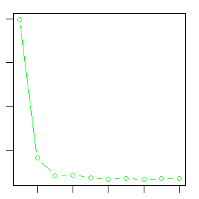

```r
library(energy)

sk <- function(x) {
#computes the sample skewness coeff.
xbar <- mean(x)
m3 <- mean((x - xbar)^3)
m2 <- mean((x - xbar)^2)
return( m3 / m2^1.5 )
}
alpha<-0.05
set.seed(0)
n<-30
m<-3300
para<-1:10
N<-length(para)
pwr<-numeric(N)
# critical value for the skewness test
cv<-qnorm(1-alpha/2,0,sqrt(6*(n-2)/((n+1)*(n+3))))

par(mar=c(1,1,1,1))
for (j in 1:N) {
  p<-para[j]
  sktests<-numeric(m)
  for (i in 1:m) {
    x<-rbeta(n,p,p)
    sktests[i] <- as.integer(
   shapiro.test(x)$p.value <= alpha)
  }
  pwr[j] <- mean(sktests)
}

#plot power vs parameter
plot(para,pwr,type='b',col="green")
```

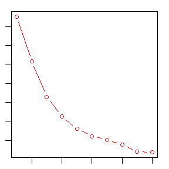

```r
for (j in 1:N) {
  p<-para[j]
  sktests<-numeric(m)
  for (i in 1:m) {
    y<-rt(n,p)
    sktests[i]<-as.integer(abs(sk(y))>=cv)
  }
  pwr[j]<-mean(sktests)
}

plot(para,pwr,type='b',col="red")
```

## Question 2

Use Monte Carlo simulation to investigate whether the empirical Type I error rate of the t-test is approximately equal to the nominal significance level α, when the sampled population is non-normal. The t-test is robust to mild departures from normality. Discuss the simulation results for the cases where the sampled population is (i) χ2(1) , (ii) Uniform(0,2), and (iii) Exponential(rate=1). In each case, test H0 : µ = µ0 vs H0 : µ = µ0,where µ0 is the mean of χ2(1), Uniform(0,2), and Exponential(1), respectively.

## Answer 2

### sample population is χ2(1)

```r
set.seed(0)
n<-50
alpha <- .05
mu0<-1
m <- 10000
#number of replicates
p <- numeric(m)
#storage for p-values
for (j in 1:m) {
  x <- rchisq(n, df=1)
  ttest <- t.test(x, alternative = "two.sided", mu = mu0)
  p[j] <- ttest$p.value
  }
p.hat <- mean(p < alpha)
print(p.hat)
```

```
## [1] 0.0755
```

### sample population is Uniform(0,2)

set.seed(0)

```r
n<-50
alpha <- .05
a<-1
mu0<-1
m <- 10000
#number of replicates
p <- numeric(m)
#storage for p-values
for (j in 1:m) {
  x <- runif(n, min=0,max=2)
  ttest <- t.test(x, alternative = "two.sided", mu = mu0)
  p[j] <- ttest$p.value
  }
p.hat <- mean(p < alpha)
print(p.hat)
```

```
## [1] 0.0529
```

### sample population is Exponential(1)

```r
n<-50
alpha <- .05
a<-1
mu0<-1
m <- 10000
#number of replicates
p <- numeric(m)
#storage for p-values
for (j in 1:m) {
  x <- rexp(n, 1)
  ttest <- t.test(x, alternative = "two.sided", mu = mu0)
  p[j] <- ttest$p.value
  }
p.hat <- mean(p < alpha)
print(p.hat)
```

```
## [1] 0.0658
```

## Discussion

If we obtain the powers for two methods under a paticular simulation setting with 10000 experiments:say,0.651 for one method and 0.676 for another method.Can we say the powers are different at 0.05 level? What is the corresponding hypothesis test problem? What test should we use?Z-test,two-sample t-test,paired-t test or McNemar test? What information is needed to test your hypothesis?

## Answer

we cannot say the power are different at 0.05 level, the corresponding hypothesis test is : H0:power1=power2 , H1:power1!=power. I think we should use McNemar test ,because McNemar test is applicable to the multiple constituent comparisons and the correlation analysis of classified data. In this validity test, we can conduct many tests to obtain the validity value of the experiment and the number of times that both methods reject at the same time when the null hypothesis is set.

## Homework 6

## Question 1

Efron and Tibshirani discuss the scor (bootstrap) test score data on 88 students who took examinations in five subjects [84, Table 7.1], [188, Table 1.2.1]. The first two tests (mechanics, vectors) were closed book and the last three tests (algebra, analysis, statistics) were open book. Each row of the data frame is a set of scores (xi1,… ,xi5)for the ith student. Use a panel display to display the scatter plots for each pair of test scores. Compare the plot with the sample correlation matrix. Obtain bootstrap estimates of the standard errors for each of the following estimates: ˆρ12 =ˆρ(mec, vec), ˆρ34 =ˆρ(alg, ana), ˆρ35 =ˆρ(alg, sta), ˆρ45 =ˆρ(ana, sta).

## Answer 1

### the scatter plots for each pair of test scores.

```r
library(boot)
```

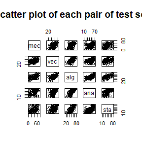

```r
data(scor,package="bootstrap")
pairs(~mec+vec+alg+ana+sta,data=scor,main="The scatter plot of each pair of test scores")
```

plot the sample correlation matrix

```r
library(corrplot)
res<-cor(scor, method = c("pearson", "kendall", "spearman"))
round(res,3)
```

```
##       mec   vec   alg   ana   sta
## mec 1.000 0.553 0.547 0.409 0.389
## vec 0.553 1.000 0.610 0.485 0.436
## alg 0.547 0.610 1.000 0.711 0.665
## ana 0.409 0.485 0.711 1.000 0.607
## sta 0.389 0.436 0.665 0.607 1.000
```

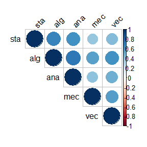

```r
corrplot(res, type = "upper", order = "hclust", tl.col = "black", tl.srt = 45)
```

### conclusion

Compare the plot with the sample correlation matrix, we can know that the sta and alg,sta and ana, alg and ana,alg and vec have strong connections. while the sta and mec, ana and mec have week connections.

```r
#set up the bootstrap

#number of replicates
set.seed(0)
B <- 200

n <- nrow(scor)
#storage for replicates
R <- numeric(B)

#bootstrap estimate of standard error of R
for (b in 1:B) {
  #randomly select the indices
  i <- sample(1:n, size = n, replace = TRUE)
  mec <- scor$mec[i]
  vec <- scor$vec[i]
  R[b] <- cor(mec, vec)
}
#output print(
se.R12 <- sd(R)
se.R12
```

```
## [1] 0.07494478
```

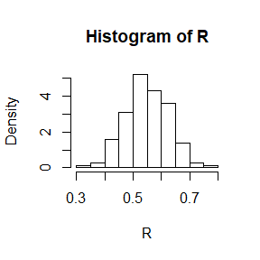

```r
hist(R, prob = TRUE)
```

```r
#set up the bootstrap

#number of replicates
B <- 200

n <- nrow(scor)
#storage for replicates
R <- numeric(B)

#bootstrap estimate of standard error of R
for (b in 1:B) {
  #randomly select the indices
  i <- sample(1:n, size = n, replace = TRUE)
  alg <- scor$alg[i]
  ana <- scor$ana[i]
  R[b] <- cor(alg, ana)
}
#output print(
se.R34 <- sd(R)
se.R34
```

```
## [1] 0.04889785
```

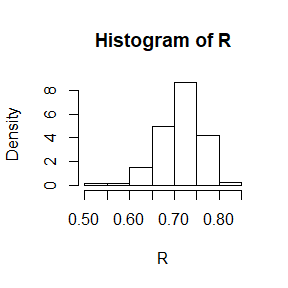

```r
hist(R, prob = TRUE)
```

```r
#set up the bootstrap

#number of replicates
B <- 200

n <- nrow(scor)
#storage for replicates
R <- numeric(B)

#bootstrap estimate of standard error of R
for (b in 1:B) {
  #randomly select the indices
  i <- sample(1:n, size = n, replace = TRUE)
  alg <- scor$alg[i]
  sta <- scor$sta[i]
  R[b] <- cor(alg, sta)
}
#output print(
se.R35 <- sd(R)
se.R35
```

```
## [1] 0.05944714
```

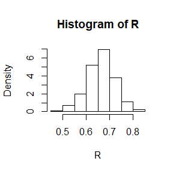

```r
hist(R, prob = TRUE)
```

```r
#set up the bootstrap

#number of replicates
B <- 200

n <- nrow(scor)
#storage for replicates
R <- numeric(B)

#bootstrap estimate of standard error of R
for (b in 1:B) {
  #randomly select the indices
  i <- sample(1:n, size = n, replace = TRUE)
  ana<- scor$ana[i]
  sta <- scor$sta[i]
  R[b] <- cor(ana, sta)
}
#output print(
se.R45 <- sd(R)
se.R45
```

```
## [1] 0.07050526
```

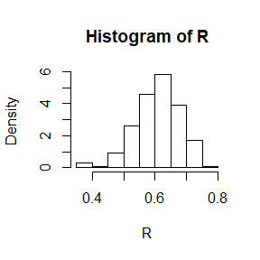

```r
hist(R, prob = TRUE)
```

```r
library(knitr)
library(kableExtra)
knitr::kable(cbind(se.R12,se.R34,se.R35,se.R45),formate = "html",col.names = c("sd of r12","sd of r34","sd of r35","sd of r45")) %>% kable_styling(position = "center")
```

| sd of r12 | sd of r34 | sd of r35 | sd of r45 |
| --- | --- | --- | --- |
| 0.0749448 | 0.0488978 | 0.0594471 | 0.0705053 |

### conclusion

From the answer,we can know that the sd of R12 is 0.0749448,sd of R34 is 0.0488978,sd of R35 is 0.0594471, sd of R45 is 0.0705053.

## Question 2

Repeat Project 7.A for the sample skewness statistic. Compare the coverage rates for normal populations (skewness 0) and χ2(5) distributions (positive skewness).

## Answer 2

### normal populations (skewness 0)

```r
n<-1e4
set.seed(1)
sk<- function(x,i) {
  #computes the sample skewness coeff
  xbar <- mean(x[i])
  m3 <- mean((x[i] - xbar)^3)
  m2 <- mean((x [i]- xbar)^2)
  return( m3 / m2^1.5 )
}

mu<-0;b<-1;m<-1e2;
library(boot)

ci.norm<-ci.basic<-ci.perc<-matrix(NA,m,2)
for(i in 1:m){
 U<-rnorm(m,0,1)
  de <- boot(data=U,statistic=sk, R = 2000)
  ci <- boot.ci(de ,type=c("norm","basic","perc"))
  ci.norm[i,]<-ci$norm[2:3];ci.basic[i,]<-ci$basic[4:5]
  ci.perc[i,]<-ci$percent[4:5]
}
cat('norm =',round(mean(ci.norm[,1]<=mu & ci.norm[,2]>=mu),4),
    'basic =',mean(ci.basic[,1]<=mu & ci.basic[,2]>=mu), 'perc =',mean(ci.perc[,1]<=mu & ci.perc[,2]>=mu))
```

```
## norm = 0.92 basic = 0.91 perc = 0.93
```

### χ2(5) distributions (positive skewness)

```r
n<-1e4
set.seed(1)
sk<- function(x,i) {
  #computes the sample skewness coeff
  xbar <- mean(x[i])
  m3 <- mean((x[i] - xbar)^3)
  m2 <- mean((x [i]- xbar)^2)
  return( m3 / m2^1.5 )
}

mu<-sqrt(8/5) # skewness of chi-square(5)
b<-1;m<-1e2;
library(boot)

ci.norm<-ci.basic<-ci.perc<-matrix(NA,m,2)
for(i in 1:m){
 U<-rchisq(m,5)
  de <- boot(data=U,statistic=sk, R = 2000)
  ci <- boot.ci(de ,type=c("norm","basic","perc"))
  ci.norm[i,]<-ci$norm[2:3];ci.basic[i,]<-ci$basic[4:5]
  ci.perc[i,]<-ci$percent[4:5]
}
cat('norm =',round(mean(ci.norm[,1]<=mu & ci.norm[,2]>=mu),4),
    'basic =',mean(ci.basic[,1]<=mu & ci.basic[,2]>=mu), 'perc =',mean(ci.perc[,1]<=mu & ci.perc[,2]>=mu))
```

```
## norm = 0.81 basic = 0.78 perc = 0.83
```

Efron and Tibshirani discuss the following example. The five-dimensional scores data have a 5 × 5 covariance matrix Σ, with positive eigenvalues λ1 > ··· >λ5. In principal components analysis,
$$\theta=\frac{\lambda_{1}}{\sum_{j=1}^{5} \lambda_{j}}$$
measures the proportion of variance explained by the first principal component. Let $\hat{\lambda}_{1}>\cdots>\hat{\lambda}_{5}$ be the eigenvalues of $\hat{\Sigma}$, where $\hat{\Sigma}$ is the MLE of $\Sigma$. Compute the sample estimate
$$\hat{\theta}=\frac{\hat{\lambda}_{1}}{\sum_{j=1}^{5} \hat{\lambda}_{j}}$$
of θ. Obtain the jackknife estimates of bias and standard error of $\hat{\theta}$.

## Answer 1

```r
library(bootstrap)
library(knitr)
n<-nrow(scor)
cov.hat<-(n-1)/n*cov(scor)
lamda_hat <- eigen(cov.hat)$values
## estimate theta_hat
theta_hat <- lamda_hat[1]/sum(lamda_hat)

n<-nrow(scor)
theta.j<-numeric(n)
ev<-matrix(nrow = 88,ncol = 5)

for (i in 1:n){ev[i,]<- eigen(cov(scor[-i,]))$values
               theta.j[i]<-ev[i,1]/sum(ev[i,])}
# estimate bias_jack
bias.jack<-(n-1)*(mean(theta.j)-theta_hat)

# estimate se.jack
se.jack<-sqrt((n-1)*mean((theta.j-mean(theta.j))^2))


print(theta_hat)
```

```
## [1] 0.619115
```

```r
print(bias.jack)
```

```
## [1] 0.001069139
```

```r
print(se.jack)
```

```
## [1] 0.04955231
```

## Question 2

In Example 7.18, leave-one-out (n-fold) cross validation was used to select the best fitting model. Repeat the analysis replacing the Log-Log model with a cubic polynomial model. Which of the four models is selected by the cross validation procedure? Which model is selected according to maximum adjusted $R^{2}$?

## Answer 2

### cross validation procedure

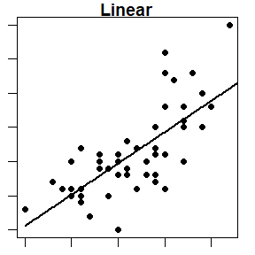

```r
library(DAAG); attach(ironslag)

a <- seq(10, 40, .1) #sequence for plotting fits

n <- length(magnetic) #in DAAG ironslag
e1 <- e2 <- e3 <- e4 <- numeric(n)

# fit models on leave-one-out samples
for (k in 1:n) {
  y <- magnetic[-k]
  x <- chemical[-k]

  # Linear model
  J1 <- lm(y ~ x)
  yhat1 <- J1$coef[1] + J1$coef[2] * chemical[k]
  e1[k] <- magnetic[k] - yhat1

  # Quadratic model
  J2 <- lm(y ~ x + I(x^2))
  yhat2 <- J2$coef[1] + J2$coef[2] * chemical[k] + J2$coef[3] * chemical[k]^2
  e2[k] <- magnetic[k] - yhat2

  # Exponential model
  J3 <- lm(log(y) ~ x)
  logyhat3 <- J3$coef[1] + J3$coef[2] * chemical[k]
  yhat3 <- exp(logyhat3)
  e3[k] <- magnetic[k] - yhat3

  # cubic polynomial model
  J4 <- lm(y~x+I(x^2)+I(x^3))
  yhat4 <- J4$coef[1] + J4$coef[2] * chemical[k] + J4$coef[3] * chemical[k]^2 +J4$coef[4] * chemical[k]^3
  e4[k] <- magnetic[k] - yhat4
}
par(mar=c(1,1,1,1))
L1 <- lm(magnetic ~ chemical)
plot(chemical, magnetic, main="Linear", pch=16)
yhat1 <- L1$coef[1] + L1$coef[2] * a
lines(a, yhat1, lwd=2)
```

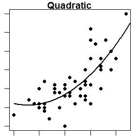

```r
L2 <- lm(magnetic ~ chemical + I(chemical^2))
plot(chemical, magnetic, main="Quadratic", pch=16)
yhat2 <- L2$coef[1] + L2$coef[2] * a + L2$coef[3] * a^2
lines(a, yhat2, lwd=2)
```

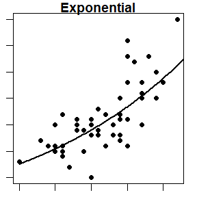

```r
L3 <- lm(log(magnetic) ~ chemical)
plot(chemical, magnetic, main="Exponential", pch=16)
logyhat3 <- L3$coef[1] + L3$coef[2] * a
yhat3 <- exp(logyhat3)
lines(a, yhat3, lwd=2)
```

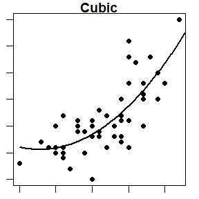

```r
L4 <- lm(magnetic ~ chemical + I(chemical^2)+I(chemical^3))
plot(chemical, magnetic, main="Cubic", pch=16)
yhat4 <- L4$coef[1] + L4$coef[2] * a + L4$coef[3] * a^2+L4$coef[4] * a^3
lines(a, yhat2, lwd=2)
```

```r
print(c(mean(e1^2), mean(e2^2), mean(e3^2), mean(e4^2)))
```

```
## [1] 19.55644 17.85248 18.44188 18.17756
```

### maximum adjusted $R^{2}$

```r
print(summary(lm(L1))$adj.r.squared)
```

```
## [1] 0.5281545
```

```r
print(summary(lm(L2))$adj.r.squared)
```

```
## [1] 0.5768151
```

```r
print(summary(lm(L3))$adj.r.squared)
```

```
## [1] 0.5280556
```

```r
print(summary(lm(L4))$adj.r.squared)
```

```
## [1] 0.5740396
```

### Conclusion

From the answer in cross validation procedure and maximum adjusted $R^{2}$ procedure,we can know that in the first procedure,the Quadratic model has better fitting effect, while in maximum adjusted $R^{2}$ procedure, linear model $R^{2}$ is 0.5281545, Quadratic model $R^{2}$ is 0.5768151, Exponential model $R^{2}$ is 0.5280556, cubic polynomial model $R^{2}$ is 0.5740396, so the Quadratic model has better fitting effect.

The Count 5 test for equal variances in Section 6.4 is based on the maximum number of extreme points. Example 6.15 shows that the Count 5 criterion is not applicable for unequal sample sizes. Implement a permutation test for equal variance based on the maximum number of extreme points that applies when sample sizes are not necessarily equal.

## Answer 1

```r
# define the cout 5 test function
count5test <- function(x, y) {
X <- x - mean(x)
Y <- y - mean(y)
outx <- sum(X > max(Y)) + sum(X < min(Y))
outy <- sum(Y > max(X)) + sum(Y < min(X))


return(as.integer(max(c(outx, outy)) > 5))
}


n1<-20
n2<-50
u1<-u2<-0
sigma1<-sigma2<-1


x<-rnorm(n1,u1,sigma1)
y<-rnorm(n2,u2,sigma2)
z<-c(x,y)
# cycle times
R<-1e4
n<-(n1+n2)/2
pool<-c(1:(n1+n2))
# storage of result
temp_result<-numeric(R)
# loop
for (i in 1:R) {
  k<-sample(pool,size=n,replace = FALSE)
  x<-z[k]
  y<-z[-k]
  temp_result[i]<-count5test(x,y)
}
# show the result
alpha_hat<-mean(temp_result)

# MC method
mm<-1e3
MC_method_result<-numeric(mm)
for (i in 1:mm) {
  xx<-rnorm(n1,u1,sigma1)
  yy<-rnorm(n2,u2,sigma2)
  zz<-c(xx,yy)
  temp_r2<-numeric(R)
  for (j in 1:R) {
  k<-sample(pool,size=n,replace = FALSE)
  nx<-zz[k]
  ny<-zz[-k]
  temp_r2[j]<-count5test(nx,ny)
  }
  MC_method_result[i]<-mean(temp_r2)
}
MC_alpha_hat<-mean(MC_method_result)
lable<-c(" one time","permutation in MC method")
result<-c(alpha_hat,MC_alpha_hat)
data.frame(lable,result)
```

```
##                      lable    result
## 1                 one time 0.0493000
## 2 permutation in MC method 0.0719338
```

## Question 2

Power comparison (distance correlation test versus ballcovariance test) Modle1:$Y=x/4+e$ Modle:$Y=X/4\times\ e$ $X \sim N\left(0_{2}, l_{2}\right), e \sim N\left(0_{2}, l_{2}\right)$

## Answer 2

### Code

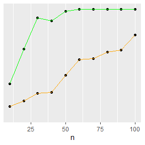

```r
library(Ball)
library(mvtnorm)
library(boot)
library(ggplot2)
# distance correlation function
dCov <- function(x, y) {
  x <- as.matrix(x); y <- as.matrix(y)
  n <- nrow(x); m <- nrow(y)
  if (n != m || n < 2) stop("Sample sizes must agree")
  if (! (all(is.finite(c(x, y)))))
  stop("Data contains missing or infinite values")
  Akl <- function(x) {
  d <- as.matrix(dist(x))
  m <- rowMeans(d); M <- mean(d)
  a <- sweep(d, 1, m); b <- sweep(a, 2, m)
  b + M
  }
A<- Akl(x); B <- Akl(y)
sqrt(mean(A * B))
}
ndCov2 <- function(z, ix, dims) {
#dims contains dimensions of x and y
p <- dims[1]
q <- dims[2]
d <- p + q
x <- z[ , 1:p] #leave x as is
y <- z[ix, -(1:p)] #permute rows of y
return(nrow(z) * dCov(x, y)^2)
}
# generate sample
n<-seq(from=10,to=100,by=10)
# loop
k<-100
# significant level
alpha<-0.05
pow_dCor_Model1<-pow_ball_Model1<-pow_dCor_Model2<-pow_ball_Model2<-numeric(length(n))
for (j in 1:length(n)) {

  #storage of temp data
  p_ball1<-numeric(k)
  dcor1<-numeric(k)
  p_ball2<-numeric(k)
  dcor2<-numeric(k)
  dcor1<-dcor2<-p_ball1<-p_ball2<-numeric(k)
  for (i in 1:k) {
    set.seed(i)
    # the function "rmvnorm" is used to
    # generate the multidimensional normal data
    X<-rmvnorm(n[j],rep(0,2),diag(1,2))
    err<-rmvnorm(n[j],rep(0,2),diag(1,2))
    Y1<-(X/4)+err
    Y2<-(X/4)*err
    Z1<-cbind(X,Y1)
    Z2<-cbind(X,Y2)
    t1<-bcov.test(X,Y2,R=99)
    p_ball1[i]<-t1$p.value
    boot.obj1<-boot(data=Z1,statistic=ndCov2,R=99,sim="permutation",dims=c(2, 2))
    temp1<-c(boot.obj1$t0, boot.obj1$t)
    dcor1[i]<-mean(temp1>=temp1[1])

    t2<-bcov.test(X,Y2,R=99)
    p_ball2[i]<-t2$p.value
    boot.obj2<-boot(data=Z2,statistic=ndCov2,R=99,sim="permutation",dims=c(2, 2))
    temp2<-c(boot.obj2$t0, boot.obj2$t)
    dcor2[i]<-mean(temp2>=temp2[1])
    }
  pow_dCor_Model1[j]<-mean(dcor1<alpha)
  pow_ball_Model1[j]<-mean(p_ball1<alpha)
  pow_dCor_Model2[j]<-mean(dcor2<alpha)
  pow_ball_Model2[j]<-mean(p_ball2<alpha)
}
dat<-data.frame(pow_dCor_Model1,pow_ball_Model1,pow_dCor_Model2,pow_ball_Model2)

ggplot(dat,aes(n))+geom_point(y=pow_dCor_Model1,fill="white")+geom_line(y=pow_dCor_Model1,colour="orange")+geom_point(y=pow_ball_Model1,fill="white")+geom_line(y=pow_ball_Model1,colour="green")
```

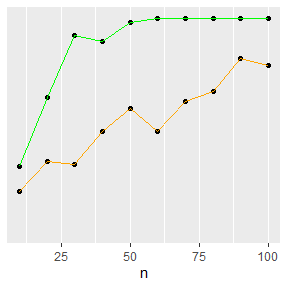

```r
ggplot(dat,aes(n))+geom_point(y=pow_dCor_Model2,fill="white")+geom_line(y=pow_dCor_Model2,colour="orange")+geom_point(y=pow_ball_Model2,fill="white")+geom_line(y=pow_ball_Model2,colour="green")
```

## Homework 9

## Question

Implement a random walk Metropolis sampler for generating the standard Laplace distribution (see Exercise 3.2). For the increment, simulate from a normal distribution. Compare the chains generated when different variances are used for the proposal distribution. Also, compute the acceptance rates of each chain.

## Answer

```r
set.seed(0)
lap_fun<-function(x){
  return(1/2*exp(-abs(x)))
}
rw.Metropolis <- function(n, sigma, x0, N) {
  x <- numeric(N)
  x[1] <- x0
  u <- runif(N)
  k<-0
  for (i in 2:N) {
    y <- rnorm(1, x[i-1], sigma)
    if (u[i] <= (lap_fun(y)/ lap_fun(x[i-1])))
      x[i] <- y else
        { x[i] <- x[i-1]
        k<-k+1
} }
return(list(x=x, k=k))
}

N <- 2000
sigma <- c(.05, .5, 2, 16)
x0 <- 25
rw1 <- rw.Metropolis(n, sigma[1], x0, N)
rw2 <- rw.Metropolis(n, sigma[2], x0, N)
rw3 <- rw.Metropolis(n, sigma[3], x0, N)
rw4 <- rw.Metropolis(n, sigma[4], x0, N)

#number of candidate points rejected
print(c(rw1$k, rw2$k, rw3$k, rw4$k))
```

```
## [1]   46  335  932 1786
```

```r
library(knitr)
library(kableExtra)
knitr::kable(cbind(1-rw1$k/N,1-rw2$k/N,1-rw3$k/N,1-rw4$k/N),formate = "html",col.names = c("acceptance rates of c1","acceptance rates of c2","acceptance rates of c3","acceptance rates  of c4")) %>% kable_styling(position = "center")
```

| acceptance rates of c1 | acceptance rates of c2 | acceptance rates of c3 | acceptance rates of c4 |
| --- | --- | --- | --- |
| 0.977 | 0.8325 | 0.534 | 0.107 |

```r
library(VGAM)
```

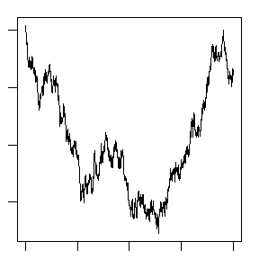

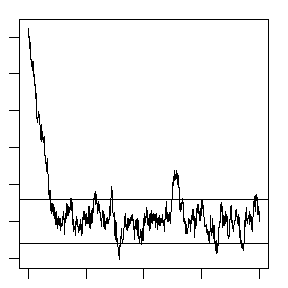

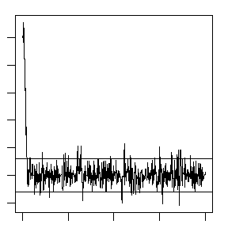

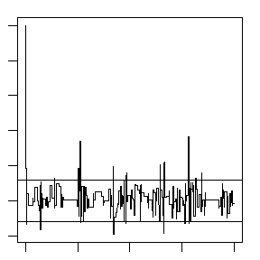

```r
par(mar=c(1,1,1,1))
    refline <- qlaplace(c(.025, .975))
    rw <- cbind(rw1$x, rw2$x, rw3$x,  rw4$x)
    for (j in 1:4) {
        plot(rw[,j], type="l",
             xlab=bquote(sigma == .(round(sigma[j],3))),
             ylab="X", ylim=range(rw[,j]))
        abline(h=refline)
    }
```

```r
 par(mfrow=c(1,1)) #reset to default

    a <- c(.05, seq(.1, .9, .1), .95)
    Q <- qlaplace(a, 0, 1)
    rw <- cbind(rw1$x, rw2$x, rw3$x, rw4$x)
    mc <- rw[501:N, ]
    Qrw <- apply(mc, 2, function(x) quantile(x, a))
    qq <- data.frame(round(cbind(Q, Qrw), 3))
    names(qq) <- c('True','sigma=0.05','sigma=0.5','sigma=2','sigma=16')
    knitr::kable(qq,format='html')%>% kable_styling(position = "center")
```

|  | True | sigma=0.05 | sigma=0.5 | sigma=2 | sigma=16 |
| --- | --- | --- | --- | --- | --- |
| 5% | -2.303 | 21.786 | -3.050 | -2.222 | -2.307 |
| 10% | -1.609 | 21.852 | -2.146 | -1.570 | -1.843 |
| 20% | -0.916 | 22.004 | -1.032 | -0.933 | -0.927 |
| 30% | -0.511 | 22.243 | -0.446 | -0.581 | -0.358 |
| 40% | -0.223 | 22.450 | -0.088 | -0.200 | 0.100 |
| 50% | 0.000 | 22.637 | 0.170 | 0.033 | 0.270 |
| 60% | 0.223 | 22.803 | 0.481 | 0.338 | 0.603 |
| 70% | 0.511 | 23.005 | 0.888 | 0.558 | 1.145 |
| 80% | 0.916 | 23.597 | 1.519 | 0.985 | 1.451 |
| 90% | 1.609 | 24.443 | 2.508 | 1.770 | 1.799 |
| 95% | 2.303 | 24.599 | 3.631 | 2.611 | 2.165 |

## Conclusion

The natural logarithm and exponential functions are inverses of each other, so that mathematically log(exp x)=exp(log x)= x. Show by example that this property does not hold exactly in computer arithmetic. Does the identity hold with near equality? (See all.equal.)

# Answer 1

```r
x1<-log(exp(100))
y1<-exp(log(100))
x2<-log(exp(15))
y2<-exp(log(15))

isTRUE(all.equal(x1,y1))
```

```
## [1] TRUE
```

```r
identical(x1,y1)
```

```
## [1] FALSE
```

```r
isTRUE(all.equal(x2,y2))
```

```
## [1] TRUE
```

```r
identical(x2,y2)
```

```
## [1] TRUE
```

# conclusion

we can know from the answer ,the natural logarithm and exponential functions does not hold exactly in computer arithmetic. when use all.equal,the answer is true, when uses identical, the answer may diffeerent.